# Week 6: Probability and statistical inference II

GV900 Political Explanation

Daina Chiba

02 October, 2019

# Topics for today

We have three main goals for this week’s lab session:

1. Univariate analyses and data manipulation (review)
2. Bivariate analysis (difference of means test)
3. Drawing maps with R

# Preparation

## Load R packages

Load necessary packages.

```r
library(tidyverse)
library(stargazer)
library(ggbeeswarm)
library(rworldmap)
```

If you encounter any error message when loading the above packages, you will need to install them. If you didn’t get any error message, skip to Section 1.

```r
install.packages("tidyverse", dependencies = TRUE)
install.packages("stargazer", dependencies = TRUE)
install.packages("ggbeeswarm", dependencies = TRUE)
install.packages("rworldmap", dependencies = TRUE)
```

After installation, load the packages.

```r
library(tidyverse)
library(stargazer)
library(ggbeeswarm)
library(rworldmap)
```

# 1. Univariate analysis

## Load the worlddata.csv data set

```r
wd <- read_csv("worlddata.csv")
```

We will analyze the relationship between `pr` (proportional representation system; we treat this as X) and `femalerep` (female representation as measured by percentage women in congress; we treat this as Y) in order to test the hypothesis that female representation is better in countries that implement a proportional representation (PR) system.

That is, our hypothesis is that the mean of `femalerep` is higher for countries with a PR system than for countries without a PR system.

Before doing any bivariate statistical analysis, we should investigate the variables individually (i.e., do univariate analyses) first, to get to know the data.

## Analyze Y

```r
summary(wd$femalerep)
```

```
   Min. 1st Qu.  Median    Mean 3rd Qu.    Max.    NA's
   0.00   14.15   20.55   22.37   31.00   61.30       4
```

This is a numerical (interval-level) variable, measured as percentage women in congress, as we have learned before. Notice that there are 4 observations with NAs. We’d better get rid of them before doing the analyses to make the subsequent programming simpler.

Let’s create a smaller data set that excludes NAs for `femalerep` and `pr`.

```r
wd.pr <- wd %>% filter(is.na(femalerep) == FALSE & is.na(pr) == FALSE)
```

Let’s make sure that we did this correctly.

```r
summary(wd.pr$femalerep)
```

```
   Min. 1st Qu.  Median    Mean 3rd Qu.    Max.
   0.00   14.15   20.55   22.48   31.00   61.30
```

We can see that NA cases have been correctly removed.

## Analyze X

Let’s now analyze the `pr` variable.

```r
summary(wd.pr$pr)
```

```
   Length     Class      Mode
      166 character character
```

Since this is a categorical (nominal-level) variable, stored as a character variable in R, applying the `summary()` function is not useful. Instead, we use the `table()` function to create a frequency table.

```r
table(wd.pr$pr)
```

```
 No Yes
 58 108
```

We can see that 108 countries have a value “Yes” and 58 countries have a value “No”. These values are not quite intuitive. Let’s re-label this variable using the `recode()` function. Let’s store the re-labeled variable as a new variable in `wd`.

```r
wd.pr$prsys <- recode(wd.pr$pr, Yes = "PR system", No = "Non-PR system")
```

Every time we make this kind of transformation, it’s a good idea to check if it worked properly. We could do so by creating a two-by-two table of values of the original `pr` variable and the newly created `prsys` variable, as follows.

```r
table(wd.pr$pr, wd.pr$prsys)
```

```
      Non-PR system PR system
  No             58         0
  Yes             0       108
```

We can see that the transformation worked as we intended.

Now that we have cleaned up the data set, let’s do a bit more extensive univariate analyses.

## Describe Y (numerically and graphically)

### Numerical summary

```r
wd.pr %>% select(femalerep) %>% as.data.frame() %>% stargazer(type = "text")
```

```
============================================================
Statistic  N   Mean  St. Dev.  Min  Pctl(25) Pctl(75)  Max
------------------------------------------------------------
femalerep 166 22.476  11.692  0.000  14.150   31.000  61.300
------------------------------------------------------------
```

### Graphical summary

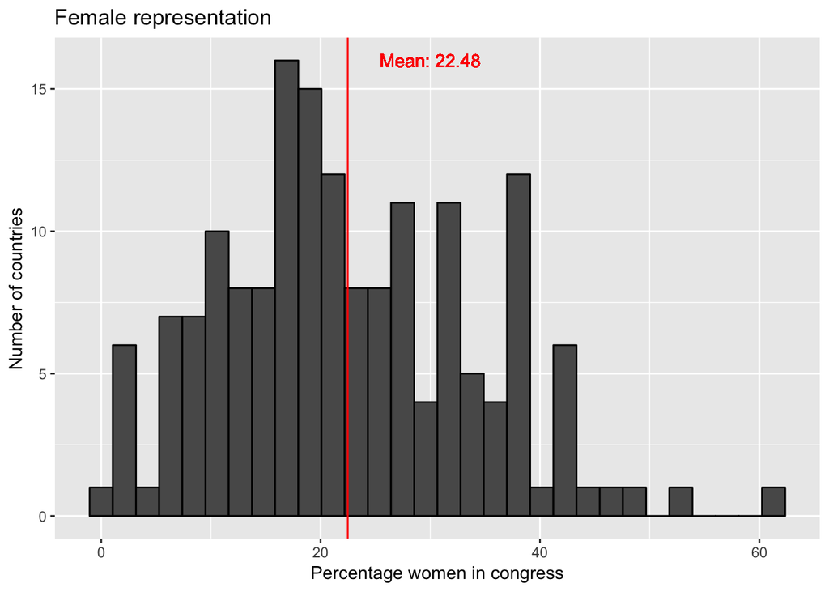

```r
m.femrep <- mean(wd.pr $ femalerep) %>% round(2)
hist1 <- ggplot(wd.pr, aes(x = femalerep)) +
  geom_histogram(color="black") +
  geom_vline(xintercept = m.femrep, color="red") +
  geom_text(x = 30, y = 16,
    label = str_c("Mean: ", m.femrep), color = "red") +
  labs(x = "Percentage women in congress",
    y = "Number of countries",
    title = "Female representation")
print(hist1)
```

```r
# ggsave(file = "figs/hist_femrep.pdf", width = 8, height = 6)
```

## Describe X (numerically and graphically)

### Numerical summary (frequency table)

```r
table(wd.pr$prsys)
```

```
Non-PR system     PR system
           58           108
```

We could make a more elaborate frequency table, as we did in Exercises for Week 4.

```r
ftbl.pr <- table(wd.pr$prsys) %>% as.data.frame()
ftbl.pr$Percentage <- round(prop.table(ftbl.pr$Freq) * 100, 2)
colnames(ftbl.pr)[colnames(ftbl.pr) == "Var1"] <- "Electoral System"
ftbl.pr
```

```
  Electoral System Freq Percentage
1    Non-PR system   58      34.94
2        PR system  108      65.06
```

### Graphical summary (bar chart)

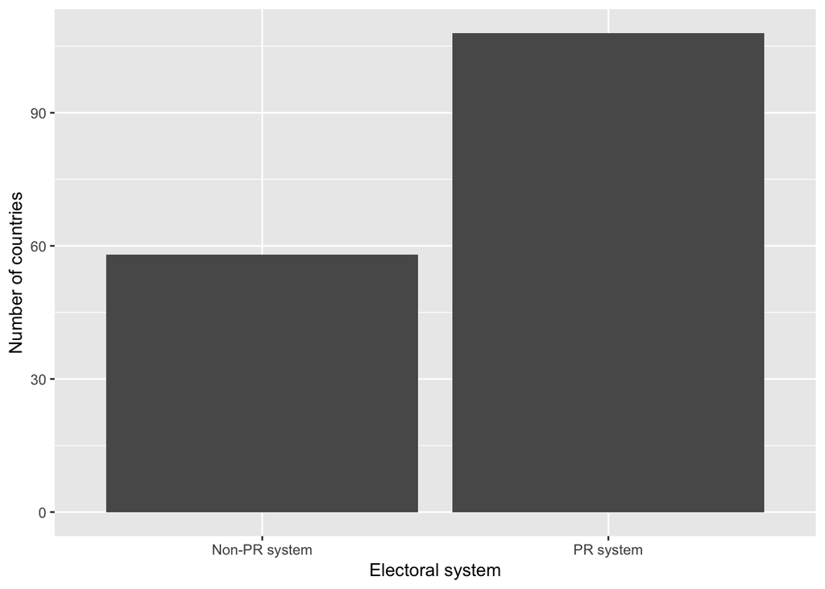

```r
bar1 <- ggplot(wd.pr, aes(x = prsys)) +
  geom_bar() +
  labs(x="Electoral system", y = "Number of countries")
print(bar1)
```

```r
# ggsave(file = "figs/bar_pr.pdf", width = 5, height = 4)
```

# 2. Bivariate analysis

Now that we have done univariate analyses (i.e., describe x and y individually), we will now do a bivariate analysis (i.e., describe the x-y relationship).

As I said, what we will do is to compare the values of Y (`femalerep`) for different values of X (PR or Non-PR). That is, we will

1. draw histograms/boxplots of Y for PR and Non-PR, and
2. calculate statistics (mean, sd, etc.) for PR and Non-PR

Let’s first do this graphically.

## Describe X-Y graphically

### Histograms, arranged horizontally

We will just add one line of code to the histogram we have already written above. That is,

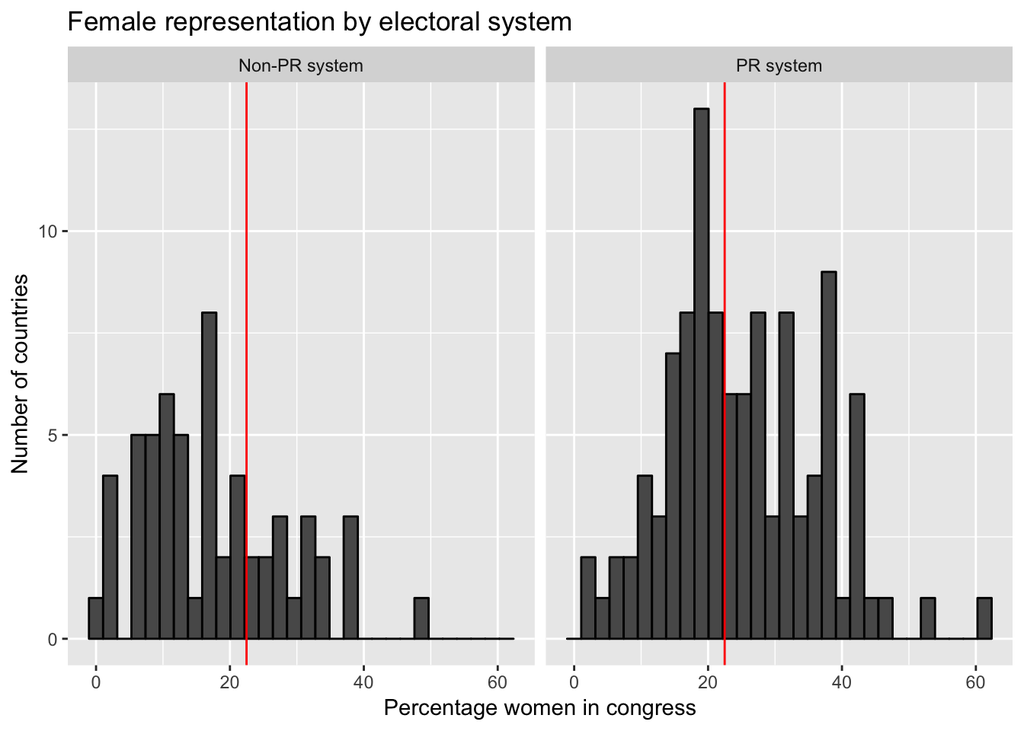

```r
hist2 <- hist1 + facet_grid(~ prsys) +
  labs(x = "Percentage women in congress",
    y = "Number of countries",
    title = "Female representation by electoral system")
print(hist2)
```

```r
# ggsave(file = "figs/hist_femrep_pr1.pdf", width = 6, height = 6)
```

It’s probably better to arrange the histograms vertically, as follows:

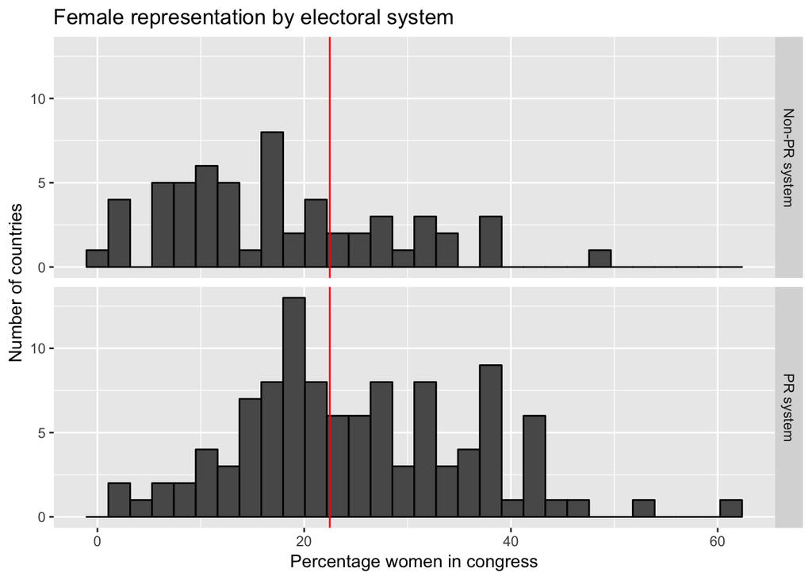

```r
# Notice that we need a period (.) after ~
hist3 <- hist1 + facet_grid(prsys ~ .) +
    labs(x = "Percentage women in congress",
    y = "Number of countries",
    title = "Female representation by electoral system")
print(hist3)
```

```r
# ggsave(file = "figs/hist_femrep_pr2.pdf", width = 6, height = 6)
```

Comparing the two histograms, we can see that `femalerep` takes higher values for PR countries than for Non-PR countries, consistent with our expectation.

Another option is to draw box plot / violin plot.

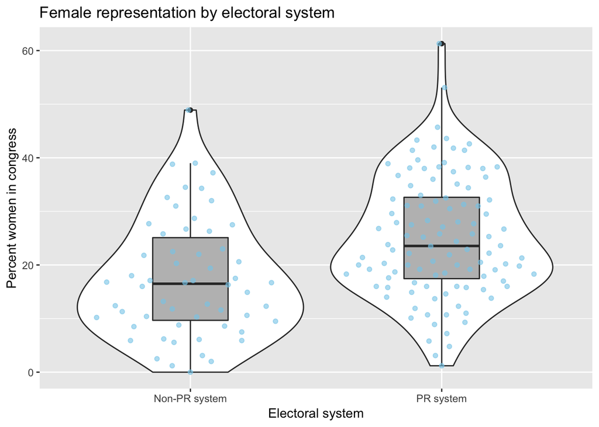

```r
bvs.pr <- ggplot(wd.pr, aes(x = prsys, y = femalerep)) +
  geom_violin() +
  geom_boxplot(width = 0.3, fill = "gray") +
  labs(x = "Electoral system",
    y = "Percent women in congress",
    title = "Female representation by electoral system") +
  geom_quasirandom(color="skyblue", alpha = 3/5)
print(bvs.pr)
```

```r
# ggsave(file = "figs/box_femrep_pr.pdf", width = 6, height = 6)
```

Let’s now do this numerically.

## Describe X-Y numerically

One way to do this is to use the `group_by()` function in combination with the `summarise()` function.

```r
wd.pr %>% group_by(prsys) %>%
  summarise(n = n(),
    mean = mean(femalerep),
    sd = sd(femalerep),
    min = min(femalerep),
    max = max(femalerep))
```

```
# A tibble: 2 x 6
  prsys             n  mean    sd   min   max
  <chr>         <int> <dbl> <dbl> <dbl> <dbl>
1 Non-PR system    58  17.5  11.0   0    48.9
2 PR system       108  25.1  11.2   1.2  61.3
```

Alternatively, we could use the `by()` function to get similar statistics, as follows:

```r
by(data = wd.pr $ femalerep,   # This part provides Y (data)
   INDICES = wd.pr $ prsys,    # This part provides X (indices)
   FUN = summary)              # This part provides what you want to do.
```

```
wd.pr$prsys: Non-PR system
   Min. 1st Qu.  Median    Mean 3rd Qu.    Max.
  0.000   9.675  16.500  17.515  25.100  48.900
--------------------------------------------------------
wd.pr$prsys: PR system
   Min. 1st Qu.  Median    Mean 3rd Qu.    Max.
   1.20   17.45   23.55   25.14   32.62   61.30
```

We can see that `femalerep` is indeed higher for PR countries in terms of all statistics (median, mean, min, max, and other quartile values). This confirms what we saw graphically and is consistent with our expectation.

The question now is: how strong is this relationship? Is it strong enough for us to say confidently that this relationship is NOT due to random chance?

To answer this question, we have to conduct a **difference of means** test (t-test).

## Difference of means test

We use the `t.test()` function to perform this test.

```r
t.test( femalerep ~ prsys, # This part specifies Y ~ X
        data = wd.pr,      # This part provides a data frame
        var.equal = TRUE)  # This option tells R to assume equal variance (let's not worry about this for now).
```

```
    Two Sample t-test

data:  femalerep by prsys
t = -4.2045, df = 164, p-value = 4.292e-05
alternative hypothesis: true difference in means is not equal to 0
95 percent confidence interval:
 -11.207634  -4.044748
sample estimates:
mean in group Non-PR system     mean in group PR system
                   17.51483                    25.14102
```

To report this finding, we say something like the following:

*Mean female representation level is 25.14% for countries with a PR system, whereas it is 17.51% for countries without a PR system. The difference of means between the two is 7.63 percentage points, yielding a t-statistic of 4.2045 with a p-value smaller than 0.001. We thus find statistical support for our hypothesis at the 99.9% confidence level.*

# 3. Drawing maps with R

A nice way to illustrate spatial distribution of variables is to create a map that shows different values on a map.

To draw a world map, we will use the `rworldmap` package, which we have loaded above.

```r
library(rworldmap)
```

To draw a map, we need two pieces of information. First, we need coordinates (longitudes and latitudes) to draw shapes (countries, regions, cities, electoral districts, etc.). Second, we need variables to be plotted.

The first piece of information is included in the `rworldmap` package, whereas the second piece of information can be some variables included in the `worlddata` data set. So, the first thing we need to do is to combine the two pieces together. We use the `joinCountryData2Map()` function (from the `rworldmap` package) to do this.

In combining two data sets, we need an ID variable that uniquely identifies rows in each of the two data sets. For example, coordinate values for the United Kingdom must be matched with the value of women09 for the United Kingdom, etc.

```r
map.dat <- joinCountryData2Map(
  dF = wd,
  joinCode = "ISO3",
  nameJoinColumn = "iso3c",
  verbose = TRUE)
```

```
174 codes from your data successfully matched countries in the map
0 codes from your data failed to match with a country code in the map
     failedCodes failedCountries
71 codes from the map weren't represented in your data
```

The code above does the following:

- The `dF` option (short for data frame) provides the name of a data frame that contains variables we want to plot.
- The `joinCode` option specifies how countries are referenced. That is, are they referred to with country names (e.g., “United Kingdom”), country abbreviations (e.g., UK, UKG, GB, etc.), country codes (200, 365, etc.)? We are using 3-digit ISO code stored in the `wd` data set, so we write `ISO3` here.
- The `nameJoinColumn` option specifies which variable included in the data frame contains the ID variable we use to match two data sets. In our case, it is the `iso3c` variable.
- The `verbose = TRUE` option tells R to give us warnings if there are some mismatches.

So, R gives us message, saying that the matching was successful for 174 countries. This means that, for 174 countries, we have both coordinates data and variables from the `wd` data set.

R also tells us that, for 71 countries, matching didn’t work. That is, there are 71 countries that exist in the map data but not in the `wd` data.

Now we are ready to plot any variables included in the `wd` onto a map.

To draw a world map, we use the `mapCountryData()` function, as follows.

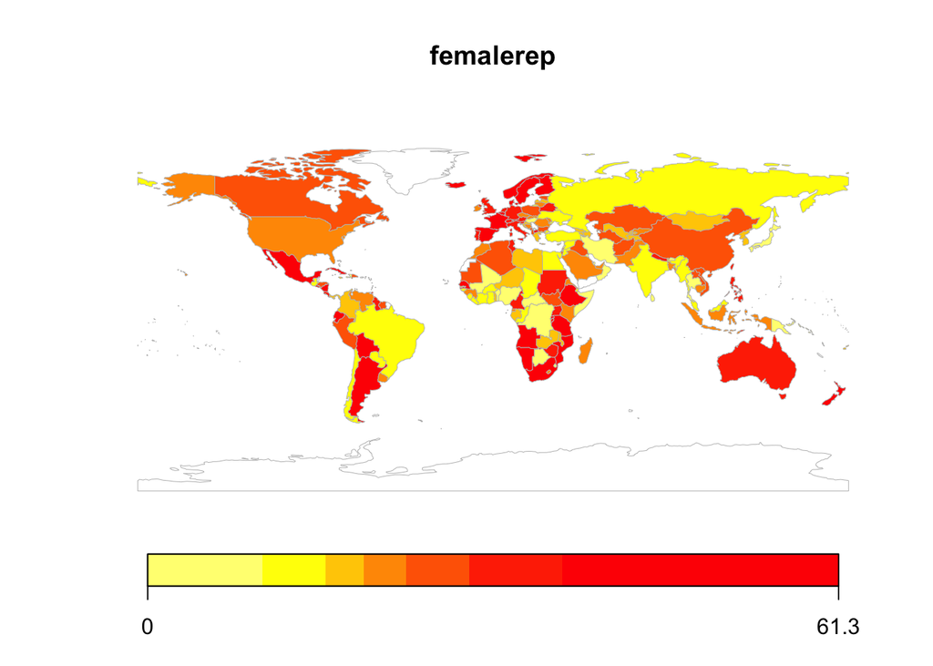

```r
mapCountryData(mapToPlot = map.dat, nameColumnToPlot = "femalerep")
```

We can modify the appearances of this using some options.

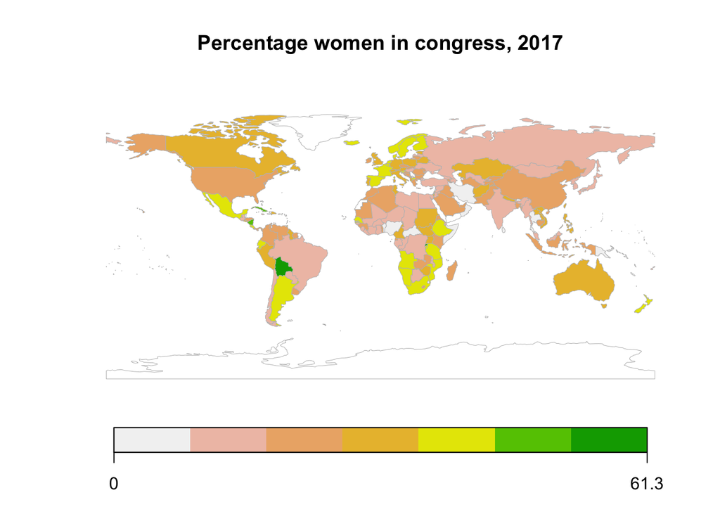

```r
mapCountryData(mapToPlot = map.dat,
  nameColumnToPlot = "femalerep",
  colourPalette = "terrain",
  catMethod = "fixedWidth",
  mapTitle = "Percentage women in congress, 2017")
```

The `colourPalette` option lets us change the coloring scheme. You can choose from the following: “heat”, “diverging”, “white2Black”, “black2White”, “topo”, “rainbow”, “terrain”, “negpos8”, “negpos9”.

Try using each to see what happens.

If you want to remove Antarctica from the map, we can do so using the `subset()` function, as follows:

```r
map.dat <- subset(map.dat, continent != "Antarctica")
```

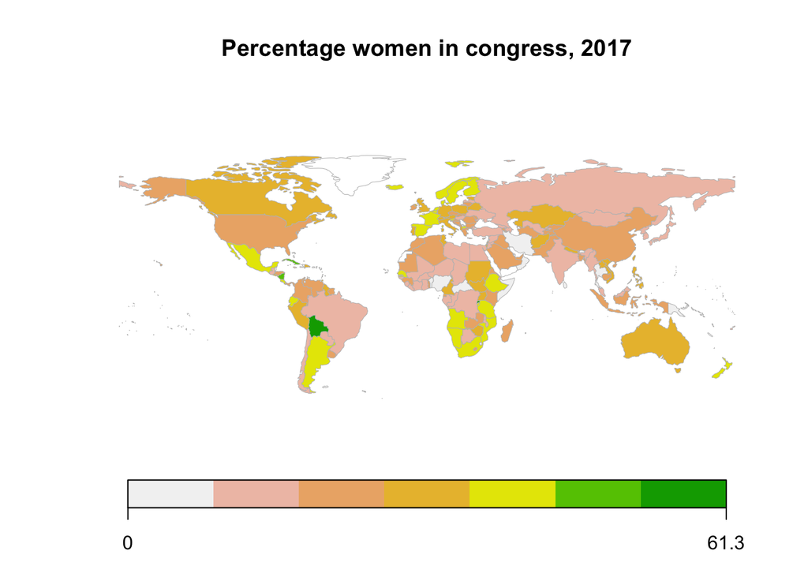

```r
mapCountryData(mapToPlot = map.dat,
  nameColumnToPlot = "femalerep",
  colourPalette = "terrain",
  catMethod = "fixedWidth",
  mapTitle = "Percentage women in congress, 2017")
```

## Saving the map

To save a map in a PDF file, we specify the file name using the `mapDevice()` function, as follows.

```r
# Run the following code chunk at once:
mapDevice(device = "pdf", file = "map_femrep.pdf", width=10, height=6)
mapCountryData(mapToPlot = map.dat,
  nameColumnToPlot = "femalerep",
  colourPalette = "terrain",
  catMethod = "fixedWidth",
  mapTitle = "Percentage women in congress, 2017")
dev.off() # This line "closes" the file we "opened" with mapDevice().
```

NB: when saving a graph using the `mapDevice()` function, you have to close the file with the `dev.off()` function.

If you fial to do `dev.off()` after you do `mapDevice()`, you will not be able to view the PDF file.

Now, go to the current folder and find the PDF file.

# Let’s try plotting other variables:

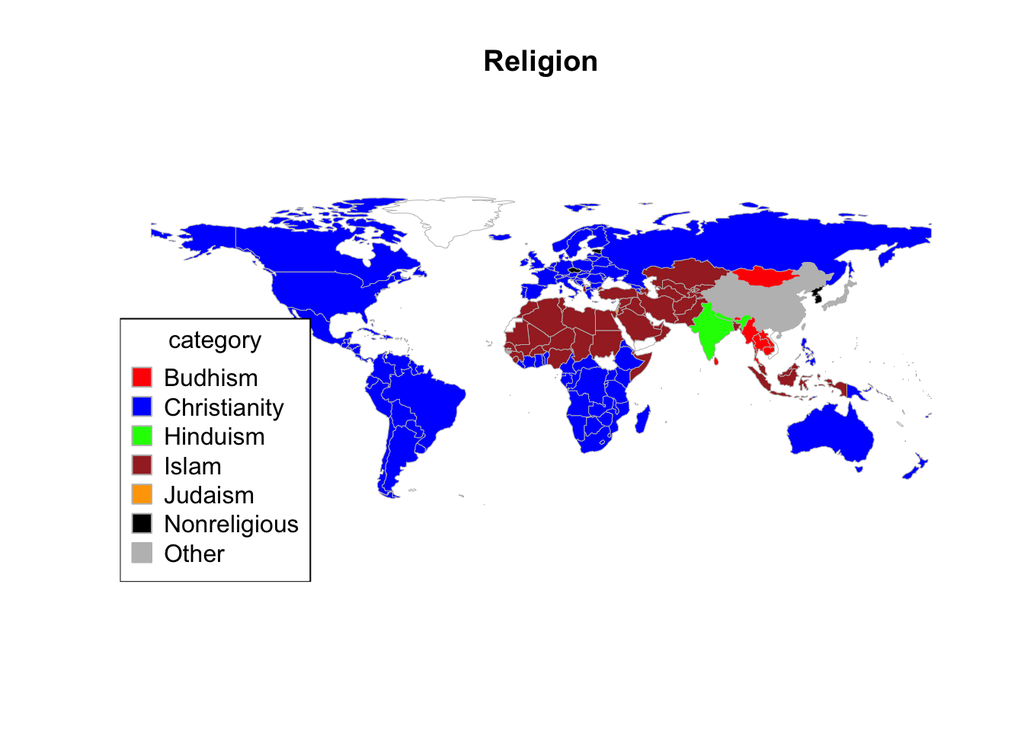

```r
mapCountryData(mapToPlot = map.dat,
  nameColumnToPlot = "religion",
  colourPalette = c("red", "blue", "green", "brown", "orange", "black", "gray"),
  catMethod = "categorical",
  mapTitle = "Religion")
```

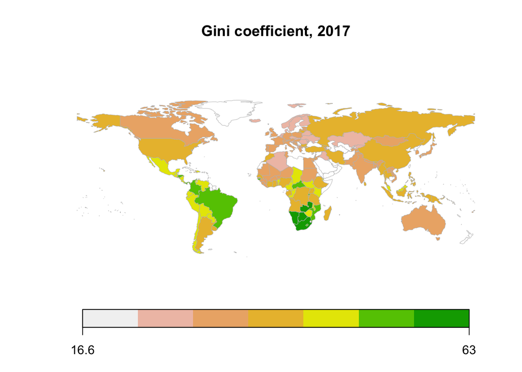

```r
mapCountryData(mapToPlot = map.dat,
  nameColumnToPlot = "gini",
  colourPalette = "terrain",
  catMethod = "fixedWidth",
  mapTitle = "Gini coefficient, 2017")
```

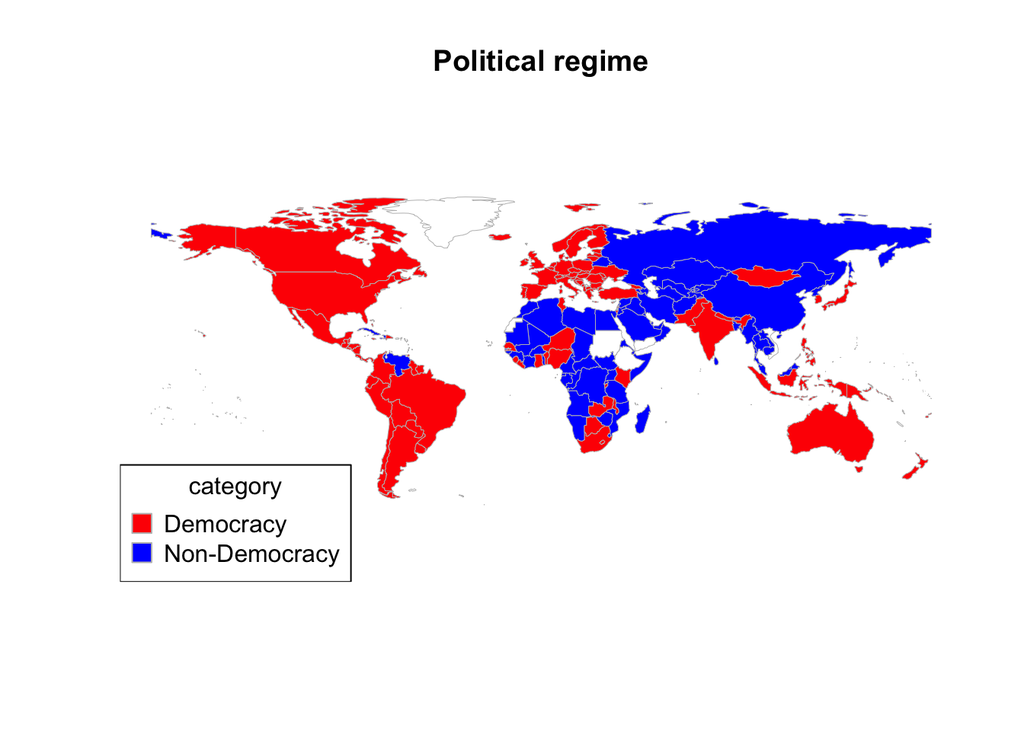

```r
mapCountryData(mapToPlot = map.dat,
  nameColumnToPlot = "democ_bmr",
  colourPalette = c("red", "blue"),
  mapTitle = "Political regime")
```

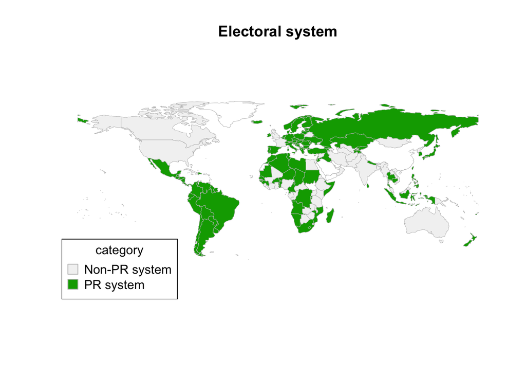

```r
map.dat $ prsys <- recode(map.dat $ pr, Yes = "PR system", No = "Non-PR system")

mapCountryData(mapToPlot = map.dat,
  nameColumnToPlot = "prsys",
  colourPalette = "terrain",
  mapTitle = "Electoral system")
```